# Coursera’s Practical Machine Learning Project

Mateusz Jukiewicz

Friday, October 24, 2014

## Getting and cleaning data

#### General data cleaning

This section shows a general process of obtaining a clean dataset from the raw data. Tidy dataset will then be used to perform exploratory data analysis and bulding the prediction model.

Note about this section: as this process is not strictly related to the asignment, and I wanted to keep this document as brief as possible, I’ve decided not to desribe the process in text, but only in code comments, so the reader can read them if she/he is interested. I am also not printing the output of this code for the same reasons. Modify the .Rmd file if you wish to see the output.

```r
## getting training and test set
trainSet <- read.csv("pml-training.csv", stringsAsFactors = FALSE)
## this is the set to submit for the assignment
testSet <- read.csv("pml-testing.csv", stringsAsFactors = FALSE)
## I've noticed that some numeric columns in the training set are factors due to
## untidy dataset. The same problem goes to test set, however the numeric
## columns there are of type logical.
## which columns in training and test set are not numeric?
notNumColsTrain <- which(!(sapply(trainSet, class) %in%
                                   c("integer", "numeric")))
notNumColsTest <- which(!(sapply(testSet, class) %in%
                                  c("integer", "numeric")))
colnames(trainSet)[notNumColsTrain]
colnames(testSet)[notNumColsTest]
## the only non numeric columns that should actually be non numeric are
## "user_name","cvtd_timestamp","new_window" (both sets) and "classe" (test set)
## specifying columns to correct
goodNotNumCols <- c("user_name", "cvtd_timestamp", "new_window")
toCorrectTrain <-
        notNumColsTrain[!notNumColsTrain %in%
                                which(colnames(trainSet) %in%
                                              c(goodNotNumCols, "classe"))]
toCorrectTest <- notNumColsTest[!notNumColsTest %in%
                                        which(colnames(testSet) %in%
                                                               goodNotNumCols)]
## correcting the columns
## numeric to numeric
trainSet[, toCorrectTrain] <- lapply(trainSet[, toCorrectTrain], as.numeric)
testSet[, toCorrectTest] <- lapply(testSet[, toCorrectTest], as.numeric)
## non numeric to factor (i don't see a problem in timestamp being factor here)
trainSet[, c(goodNotNumCols, "classe")] <-
        lapply(trainSet[, c(goodNotNumCols, "classe")], factor)
testSet[, goodNotNumCols] <- lapply(testSet[, goodNotNumCols], factor)
```

#### Data transformations based on exploratory data analysis

This section describes the exploratory data analysis and transformations of the data that I’ve performed to build as good prediction model as possible.

Note: this section is very briefly described with text and just one figure for the same reasons as for the section above. If interested in details, one can read the code comments.

I’ve supposed that variables related to specific time of when the activity was performed is not relevant to the outcome variable, that is, to “how well” the activity was performed.

I’ve also wanted to confirm that the subject ID (variable X) and name (variable user_name) are not relevant either.

Moreover, variables described above **should not** be contained in the model if they are not related to outcome, as the only thing they can introduce to the data is noise.

Here are the plots that prove those assumptions. I’ve decided not to show them as they are not too interesting (complete lack of separation between outcome classes).

```r
require(ggplot2)
qplot(cvtd_timestamp, classe, data = trainSet, colour = classe, size = 5)
qplot(raw_timestamp_part_1, classe, data = trainSet, colour = classe, size = 5)
qplot(raw_timestamp_part_2, classe, data = trainSet, colour = classe, size = 5)
qplot(raw_timestamp_part_1, raw_timestamp_part_2, data = trainSet, colour = classe, size = 5)
qplot(raw_timestamp_part_1, raw_timestamp_part_2, data = trainSet, colour = classe)
qplot(X, classe, data = trainSet, colour = classe)
qplot(user_name, classe, data = trainSet, colour = classe)
qplot(new_window, classe, data = trainSet, colour = classe)
```

I’ve managed to prove the suspected irrelevance of the variables used in plots above. However, one of the suspected variables, meaning of which I am unable to understand, seemed to possibly reveal some signal related to the outcome.

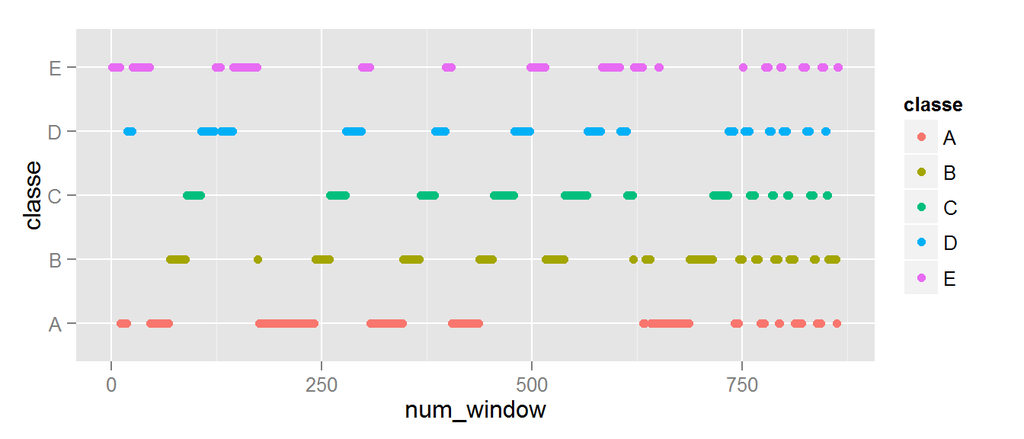

```r
require(ggplot2)
qplot(num_window, classe, data = trainSet, colour = classe)
```

I’ve kept this variable as, proven by the tests, the model performed better when with it.

Code for transforming dataset basing on exploratory analysis. It consists the removal of variables described above, as well as removal of the variables with too many missing values or zero variance.

```r
## as concluded from exploratory data analysis, the following columns are not
## relevant for specifying the outcome variable, therefore removing them:
## cvtd_timestamp, raw_timestamp_part_1, raw_timestamp_part2 - related to time of the experiment
## new_window - not sure what it is, but unrelevant (all classes for every factor)
## user_name - not important with regard to specifying outcome
## num_window - not sure what it is either, but seems to be related to outcome
## (based on tests)
trainSet <- subset(trainSet, select = -c(cvtd_timestamp, raw_timestamp_part_1,
                                         raw_timestamp_part_2, new_window,
                                         user_name))
## columns with all NA values cannot be used, checking if there are any columns
## like that and removing if so
allNACheck <- colSums(is.na(trainSet)) == nrow(trainSet)
trainSet <- trainSet[, !allNACheck]
## removing columns with more than 95% of NA's inside, as there is not enough
## information (in author's opinion) to impute those values, their variability
## would be also very low anyway
freqNACheck <- colSums(is.na(trainSet)) > nrow(trainSet)*0.95
trainSet <- trainSet[, !freqNACheck]
## checking whether there are columns with zero variance and removing them
## if so, as they give no information for any ML algorithm
zeroVarCheck <- sapply(trainSet, function(x) var(x, na.rm = T) == 0)
trainSet <- trainSet[, !zeroVarCheck]
```

**Note: all actions I’ve performed to transform the dataset were actually tested and proved they improve the model performance.**

## Building the model

This section describes the process of building a prediction model. I decided to split the data with 1:4 ratio, where the bigger part was destinied for building the estimating the model, and the smaller part was destinied for estimating the expected out of sample error.

I decided to use 10-fold cross validation to tune up the model on the training set. This was my personal choice.

I decided not to use PCA dimensionality reduction. The variables seemed not to be correlated enough for the method to improve the model performance, therefore the reduction of variability introduced by the PCA caused the model to be less efficient, according to the tests.

I tested k nearest neighbours and median for value imputation. Chose the first one as it performed better according to the tests.

```r
require(caret)
## seed for reproducibility
set.seed(910716)
## preparing sets
inTrain <- createDataPartition(y = trainSet$classe, p = 0.8, list = FALSE)
training <- trainSet[inTrain, ]
testing <- trainSet[-inTrain, ]
## using knnImpute to impute missing values
## not using PCA for compressing corelated variables
preProcObj <- preProcess(subset(training, select = -c(classe, X)),
                         method = "knnImpute")
## preprocessed training set
trainingPC <- predict(preProcObj, subset(training, select = -c(classe, X)))
## preprocessed test set
testingPC <- predict(preProcObj, subset(testing, select = -c(classe, X)))
```

I builded and tested three models totally:

- svm linear model - as I needed an easy and fast model to check if my data transformations improved the efficiency of the model or not (I could not use anything more sophisticated due to my very weak hardware setup)
- random forests - as I’ve suspected this one will perform very good in terms of prediction accuracy
- naive bayes - as a blind shot (which is very valuable strategy sometimes)

```r
modelFit0 <- train(training$classe ~ ., data=trainingPC, method="svmLinear",
                  trControl = trainControl(method = "cv", number = 10))
predictions0 <- predict(modelFit0, testingPC)
confMat0 <- confusionMatrix(predictions0, testing$classe)
```

```r
modelFit1 <- train(training$classe ~ ., data=trainingPC, method="rf",
                  trControl = trainControl(method = "cv", number = 10))
predictions1 <- predict(modelFit1, testingPC)
confMat1 <- confusionMatrix(predictions1, testing$classe)
```

```r
modelFit2 <- train(training$classe ~ ., data=trainingPC, method="nb",
                  trControl = trainControl(method = "cv", number = 10))
predictions2 <- predict(modelFit2, testingPC)
confMat2 <- confusionMatrix(predictions2, testing$classe)
```

**Last note for the graders: Note that testing few models on the testing set is not introducing overfitting. Every model was tuned up separately on the training set (using cross validation) and then applied only once to the test set.**